# Python数据处理

## 07. 来自网络的结构化数据

主讲人：丁平尖

## 网站上有很多有趣的数据

- HTML：超文本标记语言（HyperText Markup Language）
  - 基本上规定了你在互联网上看到的一切
- XML：可扩展标记语言（Extensible Markup Language）
  - 旨在成为存储数据的更简便方式，与HTML有类似的框架
- JSON：JavaScript对象表示法（JavaScript Object Notation）
  - 旨在成为XML的更合理的版本
- SQL：结构化查询语言（Structured Query Language）
  - IBM设计的语言，用于与数据库交互
- APIs：应用程序编程接口（Application Programming Interface）
  - 允许与网站功能交互（例如，谷歌地图）

## 网络数据的三个方面

- 位置：URL（统一资源定位符）、IP地址
  - 指定网络上计算机的位置
- 协议：HTTP、HTTPS、FTP、SMTP
  - 指定网络上的计算机应该如何相互通信
- 内容：HTML、JSON、XML
  - 包含实际信息，例如，告诉浏览器要显示什么以及如何显示
- 我们主要关心的是网站内容。

## 客户端-服务器模型

- 客户端 服务器
  - HTTP请求
  - HTTP响应（例如，网页）
- HTTP是
  - 无连接的：在发出请求后，客户端断开连接并等待
  - 媒体不可知的：可以通过HTTP发送任何类型的数据
  - 无状态的：服务器和客户端在请求后“忘记对方”

## URL的解剖

https://kdding.github.io/researches.html

- 协议（https）
  - 指定客户端（即你的浏览器）将如何与服务器通信。
- 主机名 （kdding.github.io）
  - 为网络上的服务器位置提供人类可读的名称。
- 文件名（researches.html）
  - 命名客户端希望访问的服务器上的特定文件。

## 在Python中访问网站：urllib

- 用于打开URL并与网站交互的Python库
  - https://docs.python.org/3/howto/urllib2.html
- 软件开发社区正在转向requests
  - https://requests.readthedocs.io/en/master/

## 使用urllib

- `urllib.request.urlopen()`：打开给定的url，返回一个类似文件的对象
- 三个基本方法
  - `getcode()`：返回响应的HTTP状态码
  - `geturl()`：返回检索到的资源的URL（例如，查看是否重定向）
  - `info()`：返回页面的元信息，例如标题

```python
import urllib.request
response = urllib.request.urlopen('https://kdding.github.io/researches.html')
type(response)
```

```
http.client.HTTPResponse
```

## getcode()

- HTTP包括成功/错误状态码
  - 例如：
    - 200 OK，请求成功。一般用于GET与POST请求;
    - 301永久移动，请求的资源已被永久的移动到新URI，返回信息会包括新的URL，浏览器会自动定向到新URI。今后任何新的请求都应使用新的URI代替
    - 404未找到，服务器无法根据客户端的请求找到资源（网页）。
    - 503服务不可用,由于超载或系统维护，服务器暂时的无法处理客户端的请求。
  - 查看https://en.wikipedia.org/wiki/List_of_HTTP_status_codes

```python
response.getcode()
```

```
200
```

## geturl()

```python
response.geturl()
```

```
'https://kdding.github.io/researches.html'
```

## info()

- 返回一个类似字典的对象，包含有关你检索到的页面的信息。

```python
print(response.info())
```

```
Connection: close
Content-Length: 23449
Server: GitHub.com
Content-Type: text/html; charset=utf-8
permissions-policy: interest-cohort=()
Last-Modified: Wed, 18 Sep 2024 09:31:34 GMT
Access-Control-Allow-Origin: *
ETag: "66ea9df6-5b99"
expires: Mon, 21 Oct 2024 06:17:18 GMT
Cache-Control: max-age=600
x-proxy-cache: MISS
X-GitHub-Request-Id: A59E:665AC:AD76A1:B9DD68:6715EF95
Accept-Ranges: bytes
Age: 287
Date: Mon, 21 Oct 2024 06:12:05 GMT
Via: 1.1 varnish
X-Served-By: cache-qpg120109-QPG
X-Cache: HIT
X-Cache-Hits: 0
X-Timer: S1729491126.713372,VS0,VE1
Vary: Accept-Encoding
X-Fastly-Request-ID: af8d8924491f6de54bedc2c924603b6ca97a3286
```

## HTML速成课程

- HTML是一种标记语言。
  - `<tag_name attr1="value" attr2="differentValue">String contents</tag_name>`
- 基本单位：标签(tag)
  - 一个开始标签和一个结束标签，如`<p>contents</p>`
- 标签的内容可能包含更多的标签：
  - `<head><title>The Title</title></head>`
  - `<p>This tag links to <a href="google.com">Google</a></p>`

## HTML速成课程

- `<tag_name attr1="value" attr2="differentValue">String contents</tag_name>`
- 标签具有属性，这些属性在标签名称后指定，以（键，值）对的形式表示为键=值
- 例如：超链接标签
  - `<a href="https://kdding.github.io">My personal webpage</a>`
  - 对应于链接到我的个人网页。
  - href属性指定超链接应该指向的位置。

## HTML速成课程：回顾

- `<tag_name attr1="value" attr2="differentValue">String contents</tag_name>`
- 标签 属性名称 属性值 内容
- https://www.w3schools.com/html/default.asp
- 一些标签介绍
  - 结构标签
    - `html`：文档根元素；`head`：文档头部；`title`：文档标题；`body`：文档主体；`header`：文档头部内容
  - 文本标签
    - `p`：段落；`span`：文本内容；`a`：超链接；`img`：图像；`br`：换行

## 回到urllib

- urllib读取一个充满HTML的网页，并返回一个“响应”对象
- 响应对象可以像文件一样处理：

```python
import urllib.request
response = urllib.request.urlopen('https://kdding.github.io/researches.html')
print(type(response))
response.read()
```

```
<class 'http.client.HTTPResponse'>
```

```
b'<!DOCTYPE html>\n<html xmlns="http://www.w3.org/1999/xhtml" lang="en" xml:lang="en"><head>\n\n<meta charset="utf-8">\n<meta name="generator" content="quarto-1.4.553">\n\n<meta name="viewport" content="width=device-width, initial-scale=1.0, user-scalable=yes">\n\n\n<title>Pingjian Ding - Researches…
```

## 在Python中解析HTML/XML：beautifulsoup

- 用于处理HTML/XML数据的Python库
  - 构建了标记数据的漂亮的树状表示...
  - 并提供了处理该树的工具
- 文档：https://www.crummy.com/software/BeautifulSoup/bs4/doc/
- 安装：
  - `pip install beautifulsoup4`
  - `conda install anaconda::beautifulsoup4`

## 示例（来自BeautifulSoup文档）

- 文档：https://www.crummy.com/software/BeautifulSoup/bs4/doc/#quick-start
- BeautifulSoup支持“漂亮打印”HTML文档。

```python
html_doc = """
<html><head><title>The Dormouse's story</title></head>
<body>
<p class="title"><b>The Dormouse's story</b></p>

<p class="story">Once upon a time there were three little sisters; and their names were
<a href="http://example.com/elsie" class="sister" id="link1">Elsie</a>,
<a href="http://example.com/lacie" class="sister" id="link2">Lacie</a> and
<a href="http://example.com/tillie" class="sister" id="link3">Tillie</a>;
and they lived at the bottom of a well.</p>

<p class="story">...</p></html>
"""
from bs4 import BeautifulSoup
parsed = BeautifulSoup(html_doc, 'html.parser')
print(parsed.prettify())
```

```
<html>
 <head>
  <title>
   The Dormouse's story
  </title>
 </head>
 <body>
  <p class="title">
   <b>
    The Dormouse's story
   </b>
  </p>
  <p class="story">
   Once upon a time there were three little sisters; and their names were
   <a class="sister" href="http://example.com/elsie" id="link1">
    Elsie
   </a>
   ,
   <a class="sister" href="http://example.com/lacie" id="link2">
    Lacie
   </a>
   and
   <a class="sister" href="http://example.com/tillie" id="link3">
    Tillie
   </a>
   ;
and they lived at the bottom of a well.
  </p>
  <p class="story">
   ...
  </p>
 </body>
</html>
```

## BeautifulSoup允许导航HTML标签

```python
print(type(parsed.title))
print(parsed.title)
```

```
<class 'bs4.element.Tag'>
<title>The Dormouse's story</title>
```

```python
parsed.title.name
```

```
'title'
```

```python
parsed.title.string
```

```
"The Dormouse's story"
```

```python
parsed.a
```

```
<a class="sister" href="http://example.com/elsie" id="link1">Elsie</a>
```

```python
# * 找到所有名为‘a’的标签，这是HTML中用于超链接的标签。
parsed.find_all('a')
```

```
[<a class="sister" href="http://example.com/elsie" id="link1">Elsie</a>,
 <a class="sister" href="http://example.com/lacie" id="link2">Lacie</a>,
 <a class="sister" href="http://example.com/tillie" id="link3">Tillie</a>]
```

```python
# * 在名为‘a’的标签中的‘href’属性包含用于超链接的实际URL。
for link in parsed.find_all('a'):
    print(link.get('href'))
```

```
http://example.com/elsie
http://example.com/lacie
http://example.com/tillie
```

## 关于属性的说明

- HTML属性和Python属性是不同的事物！
  - 但在BeautifulSoup中它们以一种奇怪的方式碰撞

```python
# BeautifulSoup标签具有可以像字典一样访问的HTML属性：
shortdoc = """
<p class="story">Once upon a time there were three little sisters; and their names were
<a href="http://example.com/elsie" class="sister" id="link1">Elsie</a>,
<a href="http://example.com/lacie" class="sister" id="link2">Lacie</a> and
<a href="http://example.com/tillie" class="sister" id="link3">Tillie</a>;
and they lived at the bottom of a well.</p>
"""
pshort = BeautifulSoup(shortdoc, 'html.parser')
print(pshort.p['class'])
```

```
['story']
```

```python
# BeautifulSoup标签具有可以作为Python属性访问的子代：
print(pshort.p.a)
```

```
<a class="sister" href="http://example.com/elsie" id="link1">Elsie</a>
```

## HTML树结构

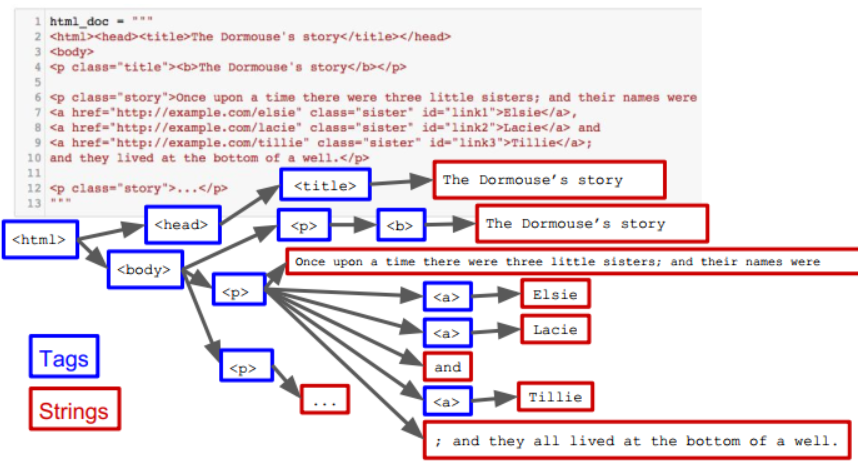

## 导航HTML树

```python
# * 通过标签名获得树中的第一个的标签
print(parsed.title)
print(parsed.a)
print(parsed.p)
```

```
<title>The Dormouse's story</title>
<a class="sister" href="http://example.com/elsie" id="link1">Elsie</a>
<p class="title"><b>The Dormouse's story</b></p>
```

```python
# * 如果标签的子代是一个字符串(叶子节点)，用tag.string访问
parsed.title.string
```

```
"The Dormouse's story"
```

```python
# * 通过标签的标签来深度遍历树
print(parsed.p.b)
```

```
<b>The Dormouse's story</b>
```

## 导航HTML树

```python
# * 用.contents访问标签的子代列表
pshort.p.contents
```

```
['Once upon a time there were three little sisters; and their names were\n',
 <a class="sister" href="http://example.com/elsie" id="link1">Elsie</a>,
 ',\n',
 <a class="sister" href="http://example.com/lacie" id="link2">Lacie</a>,
 ' and\n',
 <a class="sister" href="http://example.com/tillie" id="link3">Tillie</a>,
 ';\nand they lived at the bottom of a well.']
```

```python
# * 或者用.children获取子代信息（Python迭代器）
print(pshort.p.children)
for i in pshort.p.children:
    print(i)
```

```
<list_iterator object at 0x000001D8B80821D0>
Once upon a time there were three little sisters; and their names were

<a class="sister" href="http://example.com/elsie" id="link1">Elsie</a>
,

<a class="sister" href="http://example.com/lacie" id="link2">Lacie</a>
 and

<a class="sister" href="http://example.com/tillie" id="link3">Tillie</a>
;
and they lived at the bottom of a well.
```

```python
# * 用.descendants递归遍历树
print(pshort.p.descendants)
for i in pshort.p.descendants:
    print(i)
```

```
<generator object Tag.descendants at 0x000001D8B856DE00>
Once upon a time there were three little sisters; and their names were

<a class="sister" href="http://example.com/elsie" id="link1">Elsie</a>
Elsie
,

<a class="sister" href="http://example.com/lacie" id="link2">Lacie</a>
Lacie
 and

<a class="sister" href="http://example.com/tillie" id="link3">Tillie</a>
Tillie
;
and they lived at the bottom of a well.
```

## 导航HTML树

- 树结构意味着每个标签都有一个父标签（除了“根”标签，其父标签为“None”）。

```python
link = parsed.a
link
```

```
<a class="sister" href="http://example.com/elsie" id="link1">Elsie</a>
```

```python
# 用.parent访问标签的父标签
link.parent
```

```
<p class="story">Once upon a time there were three little sisters; and their names were
<a class="sister" href="http://example.com/elsie" id="link1">Elsie</a>,
<a class="sister" href="http://example.com/lacie" id="link2">Lacie</a> and
<a class="sister" href="http://example.com/tillie" id="link3">Tillie</a>;
and they lived at the bottom of a well.</p>
```

```python
link.parents
```

```
<generator object PageElement.parents at 0x000001E188017F40>
```

```python
# 用.parents获取回到根标签的整个父链
for parent in link.parents:
    print(parent.name)
```

```
p
body
html
[document]
```

```python
# 用.previous_sibling和.next_sibling在树中“左”和“右”移动
print(link.previous_sibling)
print(link.next_sibling)
```

```
Once upon a time there were three little sisters; and their names were

,
```

## 搜索树：find_all和相关方法

```python
# 找到所有名为‘p’的标签
parsed.find_all('p')
```

```
[<p class="title"><b>The Dormouse's story</b></p>,
 <p class="story">Once upon a time there were three little sisters; and their names were
 <a class="sister" href="http://example.com/elsie" id="link1">Elsie</a>,
 <a class="sister" href="http://example.com/lacie" id="link2">Lacie</a> and
 <a class="sister" href="http://example.com/tillie" id="link3">Tillie</a>;
 and they lived at the bottom of a well.</p>,
 <p class="story">...</p>]
```

```python
# 找到所有名称匹配‘a’或‘b’的标签
parsed.find_all(['a', 'b'])
```

```
[<b>The Dormouse's story</b>,
 <a class="sister" href="http://example.com/elsie" id="link1">Elsie</a>,
 <a class="sister" href="http://example.com/lacie" id="link2">Lacie</a>,
 <a class="sister" href="http://example.com/tillie" id="link3">Tillie</a>]
```

```python
# 找到所有名称匹配给定正则表达式的标签。
import re
parsed.find_all(re.compile(r'^b'))
```

```
[<body>
 <p class="title"><b>The Dormouse's story</b></p>
 <p class="story">Once upon a time there were three little sisters; and their names were
 <a class="sister" href="http://example.com/elsie" id="link1">Elsie</a>,
 <a class="sister" href="http://example.com/lacie" id="link2">Lacie</a> and
 <a class="sister" href="http://example.com/tillie" id="link3">Tillie</a>;
 and they lived at the bottom of a well.</p>
 <p class="story">...</p>
 </body>,
 <b>The Dormouse's story</b>]
```

## 关于find_all的更多信息

- 注意：默认情况下，find_all递归遍历整棵树，但你可以通过传递`recursive=False`标志使其只搜索标签的直接子代。
- 查看[https://www.crummy.com/software/BeautifulSoup/bs4/doc/#find-all了解更多。](https://www.crummy.com/software/BeautifulSoup/bs4/doc/#find-all%E4%BA%86%E8%A7%A3%E6%9B%B4%E5%A4%9A%E3%80%82)

```python
# 传入一个函数，该函数根据标签返回True/False，find_all将只返回评估为True的标签
def has_class_but_no_id(tag):
    return tag.has_attr('class') and not tag.has_attr('id')
parsed.find_all(has_class_but_no_id)
```

```
[<p class="title"><b>The Dormouse's story</b></p>,
 <p class="story">Once upon a time there were three little sisters; and their names were
 <a class="sister" href="http://example.com/elsie" id="link1">Elsie</a>,
 <a class="sister" href="http://example.com/lacie" id="link2">Lacie</a> and
 <a class="sister" href="http://example.com/tillie" id="link3">Tillie</a>;
 and they lived at the bottom of a well.</p>,
 <p class="story">...</p>]
```

## 内容扁平化：get_text()

```python
# 这个<p>标签包含一个完整的句子，但句子的某些部分是链接，所以p.string失败。如果我想在没有链接的情况下获取完整的字符串，我该怎么办？
print(pshort)
print(pshort.p.string is None)
```

```
<p class="story">Once upon a time there were three little sisters; and their names were
<a class="sister" href="http://example.com/elsie" id="link1">Elsie</a>,
<a class="sister" href="http://example.com/lacie" id="link2">Lacie</a> and
<a class="sister" href="http://example.com/tillie" id="link3">Tillie</a>;
and they lived at the bottom of a well.</p>

True
```

```python
pshort.p.contents
```

```
['Once upon a time there were three little sisters; and their names were\n',
 <a class="sister" href="http://example.com/elsie" id="link1">Elsie</a>,
 ',\n',
 <a class="sister" href="http://example.com/lacie" id="link2">Lacie</a>,
 ' and\n',
 <a class="sister" href="http://example.com/tillie" id="link3">Tillie</a>,
 ';\nand they lived at the bottom of a well.']
```

```python
# 注意：在BeautifulSoup中尝试访问不存在的tag.string是常见导致错误/错误的原因！
pshort.p.get_text()
```

```
'Once upon a time there were three little sisters; and their names were\nElsie,\nLacie and\nTillie;\nand they lived at the bottom of a well.'
```

## XML - 可扩展标记语言，.xml

- https://en.wikipedia.org/wiki/XML
- 核心思想：将数据与其表示分开
  - 注意HTML不这样做 - 网页的HTML也是数据
  - HTML 主要用于网页开发，XML 主要用于数据存储和交换。
- 但XML是基于标签的，与HTML非常相似
- BeautifulSoup将解析XML
  - https://www.crummy.com/software/BeautifulSoup/bs4/doc/#installing-a-parser

```python
with open('short.xml', 'r') as f:
	file = f.read()
from bs4 import BeautifulSoup
pshort = BeautifulSoup(file, 'xml')
print(pshort.prettify())
```

```
<?xml version="1.0" encoding="utf-8"?>
<teachers>
 <teacher>
  <name>
   Sam Davies
  </name>
  <age>
   35
  </age>
  <subject>
   Maths
  </subject>
 </teacher>
 <teacher>
  <name>
   Cassie Stone
  </name>
  <age>
   24
  </age>
  <subject>
   Science
  </subject>
 </teacher>
 <teacher>
  <name>
   Derek Brandon
  </name>
  <age>
   32
  </age>
  <subject>
   History
  </subject>
 </teacher>
</teachers>
```

```python
pshort.find_all('name')
```

```
[<name>Sam Davies</name>,
 <name>Cassie Stone</name>,
 <name>Derek Brandon</name>]
```

```python
for i in pshort.teachers.children:
    print(i)
```

```
<teacher>
<name>Sam Davies</name>
<age>35</age>
<subject>Maths</subject>
</teacher>


<teacher>
<name>Cassie Stone</name>
<age>24</age>
<subject>Science</subject>
</teacher>


<teacher>
<name>Derek Brandon</name>
<age>32</age>
<subject>History</subject>
</teacher>
```

## JSON - JavaScript对象表示法

- https://en.wikipedia.org/wiki/JSON
- 基本构建块：
  - 属性-值对
  - 数组数据

```python
import json
with open("example.json") as f:
    data = json.load(f)
data
```

```
{'first_name': 'John',
 'last_name': 'Smith',
 'is_alive': True,
 'age': 27,
 'address': {'street_address': '21 2nd Street',
  'city': 'New York',
  'state': 'NY',
  'postal_code': '10021-3100'},
 'phone_numbers': [{'type': 'home', 'number': '212 555-1234'},
  {'type': 'office', 'number': '646 555-4567'}],
 'children': ['Catherine', 'Thomas', 'Trevor'],
 'spouse': None}
```

## Python json模块

```python
import json
json_string = '{"first_name": "John", "last_name": "Smith",\
    "alma_mater": "Princeton University"}'
# json.loads解析字符串并返回JSON对象。
parsed_json = json.loads(json_string)
print(type(parsed_json))
parsed_json
```

```
<class 'dict'>
```

```
{'first_name': 'John',
 'last_name': 'Smith',
 'alma_mater': 'Princeton University'}
```

```python
# json.dumps将JSON对象重新转换为字符串。
json.dumps(parsed_json)
```

```
'{"first_name": "John", "last_name": "Smith", "alma_mater": "Princeton University"}'
```

## Python json模块

- 由json.loads返回的是Python字典。

```python
type(parsed_json), parsed_json
```

```
(dict,
 {'first_name': 'John',
  'last_name': 'Smith',
  'alma_mater': 'Princeton University'})
```

```python
parsed_json['first_name']
```

```
'John'
```

## JSON对象可以有非常复杂的结构

JSON对象可以有非常复杂的结构 如果你试图处理大量数据集合，这可能会很快失控。对于这样的应用程序，你最好使用数据库。

```python
with open("example2.json") as f:
    data = json.load(f)
data
```

```
{'id': '0001',
 'type': 'donut',
 'name': 'Cake',
 'ppu': 0.55,
 'batters': {'batter': [{'id': '1001', 'type': 'Regular'},
   {'id': '1002', 'type': 'Chocolate'},
   {'id': '1003', 'type': 'Blueberry'},
   {'id': '1004', 'type': "Devil's Food"}]},
 'topping': [{'id': '5001', 'type': 'None'},
  {'id': '5002', 'type': 'Glazed'},
  {'id': '5005', 'type': 'Sugar'},
  {'id': '5007', 'type': 'Powdered Sugar'},
  {'id': '5006', 'type': 'Chocolate'},
  {'id': '5003', 'type': 'Maple'},
  {'id': '5004', 'type': 'Raisin'}]}
```